# (Loan Characteristics & Borrower's APR)

## by (Hatim Alsulami)

## Investigation Overview

> In this investigation, I wanted to look at the characteristics of loans that could be used to predict the borrower APR. The main focus was on the original loan amount, borrower's Prosper rating, loan term, Employment status, borrower's stated monthly income and monthly loan's payment.

## Dataset Overview

> This data set contains 113,937 loans with 81 variables on each loan, including loan amount, borrower rate (or interest rate), current loan status, borrower income, and many others. After wrangling process we ended up with 84853 loans. We are only intrested on loans originatedfrom July 2009.

## (Distribution of Borrower APR)

> The distribution of APR looks multimodal. A small peak centered around 0.1, a large peak around at 0.2. There is also a small peak centered 0.3. Additionally, there is a very shape peak between 0.35 and 0.36

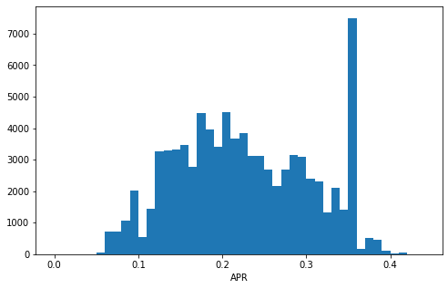

```python
# start with a standard-scaled plot
binsize = 0.025
bins = np.arange(0, df['BorrowerAPR'].max()+binsize, 0.01)

plt.figure(figsize=[8, 5])
plt.hist(data = df, x = 'BorrowerAPR', bins = bins)
plt.xlabel('APR')
plt.show()
```

## (Distribution of Original Loan Amount)

> There are spikes in frequency at 5k, 10k, 20k and 25k

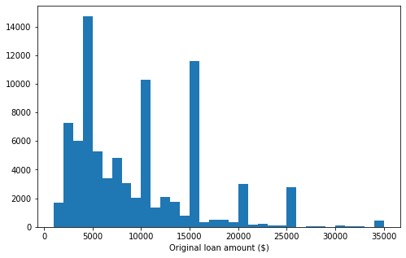

```python
bins = np.arange(1000, df.LoanOriginalAmount.max()+500, 1000)
plt.figure(figsize=[8, 5])
plt.hist(data = df, x = 'LoanOriginalAmount', bins = bins);
plt.xlabel('Original loan amount ($)');
```

## (Borrower APR vs. Loan Amount)

> We found that there's correlation between borrower APR and loan amount. The correlation coefficient is -0.426

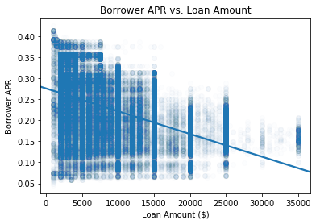

```python
sb.regplot(data = df, x = 'LoanOriginalAmount', y = 'BorrowerAPR', scatter_kws={'alpha':0.01});
plt.xlabel('Loan Amount ($)')
plt.ylabel('Borrower APR')
plt.title('Borrower APR vs. Loan Amount');
```

## (Borrower APR vs. Prosper Rating)

> The borrower APR decreases with high Prosper Rating

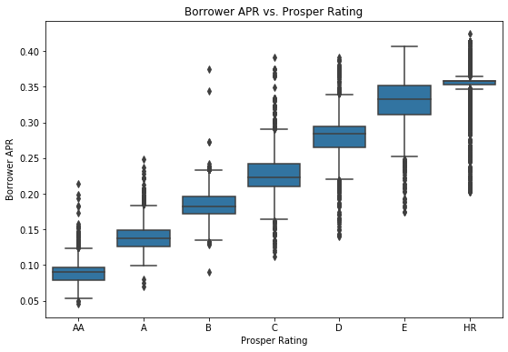

```python
plt.figure(figsize=[9,6])
default_color = sb.color_palette()[0]
rate_order = ['AA', 'A', 'B','C','D','E','HR']
sb.boxplot(data=df, x='ProsperRating', y='BorrowerAPR', color=default_color, order=rate_order)
plt.xlabel('Prosper Rating')
plt.ylabel('Borrower APR')
plt.title('Borrower APR vs. Prosper Rating');
```

## ( Prosper Rating Effect on Relationship between APR and Loan Amount)

> Rating AA and A, which are the lowest risk, have a postive correlation. From B to HR, it is negative correlation.

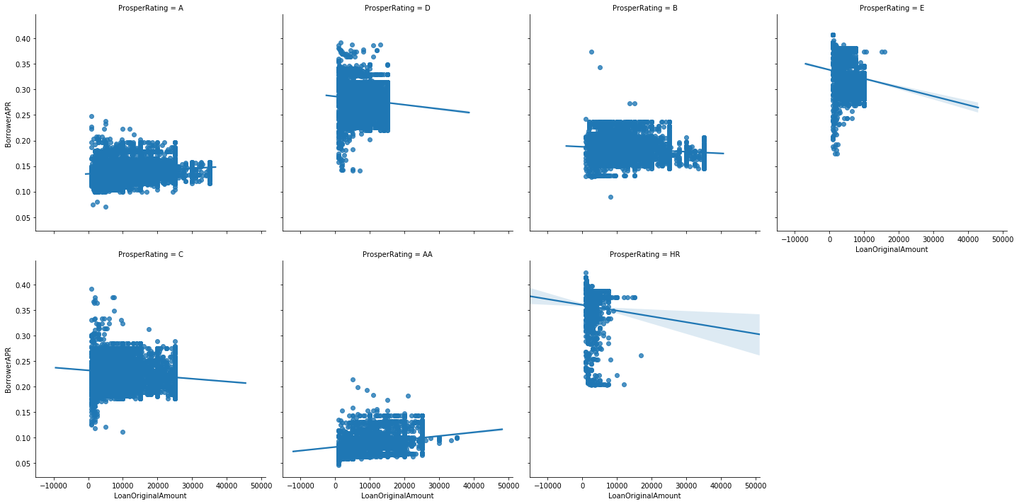

```python
# Prosper rating effect on relationship of APR and loan amount
g=sb.FacetGrid(data=df, aspect=1, height=5, col='ProsperRating', col_wrap=4)
g.map(sb.regplot, 'LoanOriginalAmount', 'BorrowerAPR');
g.add_legend();
```

## (Borrower APR by Rating and Term)

> The borrower APR decreases with the increasingly better rating. Borrowers with the best Prosper ratings have the lowest APR.

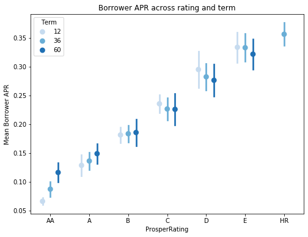

```python
rate_order =['AA', 'A', 'B', 'C', 'D', 'E', 'HR']
fig = plt.figure(figsize = [8,6])
ax = sb.pointplot(data = df, x = 'ProsperRating', y = 'BorrowerAPR', hue = 'Term', order=rate_order,
           palette = 'Blues', linestyles = '', dodge = 0.4, ci='sd')
plt.title('Borrower APR across rating and term')
plt.ylabel('Mean Borrower APR')
ax.set_yticklabels([],minor = True);
```